# A quick tutorial on computing population-specific Fst with srsStuff

# Introduction

This is a hands-on practical session to get you up and running with using the srsStuff package to compute population-specific $F_\mathrm{ST}$ from low-coverage whole genome sequencing data.

The text version of this Rmarkdown document can be found at GitHub at: https://github.com/eriqande/srsStuff/blob/master/tutorials/pop-spec-Fst-tutorial.Rmd.

The srsStuff package uses the allele-depths reported in a VCF file to do single-read sampling to allow fast and robust calculations.

There are two main steps to computing $F_\mathrm{ST}$ with srsStuff:

1. First you need to prepare data from your VCF files into a flat-text format that can be easily parsed by the C++ code engine within srsStuff.
2. Second, you must prepare the names of the individuals in your sample, designating which populations they are in (and also, the relationship between those populations, if you are interested in estimating $F_\mathrm{ST}$ along the internal branches of a tree of populations and “ancestral” populations).

These topics are covered in the next two sections.

# VCF Input Data

It is typical to have many VCF files—perhaps one for each chromosome of a chromosomal-level assembly. These have to all be concatenated into a single VCF file, and then that file can be filtered however you want to, but most importantly, it must be filtered to include **only biallelic markers**. That means biallelic SNPs and indels. After that filtering, the `bcftools query` utility is used to write out the allele depths to a simple, tab-delimited, text file for use.

I have prepared some sample data for this tutorial: two chromosomes worth of bgzipped VCF files from 160 Chinook salmon. This is about 126 Mb of data that is stored in a publicly accessible folder on my CSU google drive: https://drive.google.com/drive/folders/1lrk7IjSyCQrvFj74Zpwcexp3pdRp5Ar4?usp=sharing

If you want to follow along with this tutorial, *including the bcftools portions*, you should download the four files:

```
NC_037113.1.vcf.gz
NC_037113.1.vcf.gz.csi
NC_037114.1.vcf.gz
NC_037114.1.vcf.gz.csi
```

and put them in your `~/Downloads` directory (or wherever you might want them if you are working on a cluster…just know that you will have to account for the directory change relative to this tutorial.) This tutorial assumes that you have downloaded them one at a time to your `~/Downloads` directory. Note: *leave the the VCF files gzipped*, and don’t use Safari to download them, because that tries to open them with your address book application.

*If you don’t want to hassle with the bcftools portion*, you can just download the files:

```
two-small-chromos-flat.txt.gz
vcf_sample_names.txt
```

If you opted to download those two files then you must decompress `two-small-chromos-flat.txt.gz` with the Unix command `gunzip two-small-chromos-flat.txt.gz`.

## Catenating and filtering the VCF files

This is, of course, a job for `bcftools`. Here we chain two commands together:

1. concatenate (with `bcftools concat`)
2. filter (with `bcftools view`) And then we index the result.

```bash
cd ~/Downloads
bcftools concat NC_037113.1.vcf.gz NC_037114.1.vcf.gz | \
bcftools view -m 2 -M 2 \
    --min-af 0.01 --max-af 0.99 \
    -i 'F_MISSING < 0.5'\
    -Oz > two_small_chromos.vcf.gz
bcftools index two_small_chromos.vcf.gz
```

After that, it is useful to get an overview of how many sites and individuals we have:

```bash
bcftools stats two_small_chromos.vcf.gz | awk '$1=="SN"'
```

Which tells us that we have:

```
SN  0   number of samples:  160
SN  0   number of records:  310664
SN  0   number of no-ALTs:  0
SN  0   number of SNPs: 254483
SN  0   number of MNPs: 0
SN  0   number of indels:   56181
SN  0   number of others:   0
SN  0   number of multiallelic sites:   0
SN  0   number of multiallelic SNP sites:   0
```

Yay! 310,664 sites. That should take just a couple minutes to run through.

## Extracting the sample names and the allele depths

### Samples names as they appear in the VCF

First, we need to get the sample names in the order that the appear in the VCF file. Once again, this is a job for `bcftools`:

```bash
# you should be in the ~/Downloads directory for this
bcftools query --list-samples two_small_chromos.vcf.gz > vcf_sample_names.txt
```

Here is what the first 10 of 160 lines of that file look like:

```
DPCh_plate1_A01_S1
DPCh_plate1_A02_S2
DPCh_plate1_A03_S3
DPCh_plate1_A04_S4
DPCh_plate1_A05_S5
DPCh_plate1_A06_S6
DPCh_plate1_A07_S7
DPCh_plate1_A08_S8
DPCh_plate1_A09_S9
DPCh_plate1_A10_S10
```

It just holds the sample names, one per line.

### Getting a flat text file of allele depths

We also need to get the CHROM, POS and the allele depths fields for every individual.

```bash
# you should be in the ~/Downloads directory for this
bcftools query -f '%CHROM\t%POS[\t%AD]\n' two_small_chromos.vcf.gz > two-small-chromos-flat.txt
```

# Preparing for srsStuff and $F_\mathrm{ST}$ calculation

## Getting the srsStuff package

First off, you must have the srsStuff package installed. The easiest way to do that is like this:

```r
remotes::install_github("eriqande/srsStuff", upgrade = FALSE)
```

Note that you need to have all the build tools (like XCode on a Mac) to do this, because the package requires C++ compilation.

## Getting information about the individuals

I have included the meta data for these 160 Chinook salmon in the srsStuff package. We can get it like this:

```r
library(tidyverse)
library(srsStuff)

meta_raw <- read_csv(
  system.file(
    "extdata/wgs-chinoook-samples-cleaned.csv",
    package = "srsStuff"
  )
)
```

This file has the name of each sample and the population that it belongs to. The population names are a little cumbersome, so we shorten them up here a little bit:

```r
 meta <- meta_raw %>%
  mutate(
    pop = recode(
      Population,
      "Salmon River Fall" =  "SalmR-Fall",
      "Salmon River Spring" =  "SalmR-Spri",
      "Feather River Hatchery Fall" =  "FeatH-Fall",
      "Feather River Hatchery Spring" =  "FeatH-Spri",
      "Trinity River Hatchery Fall" =  "TrinH-Fall",
      "Trinity River Hatchery Spring" =  "TrinH-Spri",
      "San Joaquin River Fall" =  "SanJo-Fall",
      "Coleman Hatchery Late Fall" =  "ColmH-LFal",
      "Sacramento River Winter" =  "SacrR-Wint",
      "Butte Creek Spring" =  "ButtC-Spri"
    )) %>%
  rename(indiv = vcf_name) %>%
  select(indiv, pop)
```

Now we have a tibble with a column `indiv` that has the sample names in it (*as they appear in the VCF file*), and a column `pop` that says which population each sample belongs to. Here is what that looks like:

```r
meta
```

| indiv | pop |
| --- | --- |
| DPCh_plate1_A01_S1 | SalmR-Fall |
| DPCh_plate1_A02_S2 | SalmR-Fall |
| DPCh_plate1_A03_S3 | SalmR-Spri |
| DPCh_plate1_A04_S4 | SalmR-Spri |
| DPCh_plate1_A05_S5 | FeatH-Fall |
| DPCh_plate1_A06_S6 | FeatH-Fall |
| DPCh_plate1_A07_S7 | FeatH-Spri |
| DPCh_plate1_A08_S8 | FeatH-Spri |
| DPCh_plate1_A09_S9 | TrinH-Spri |
| DPCh_plate1_A10_S10 | TrinH-Spri |

[output cut: 150 more lines]

## A hierarchical tree of populations (and “ancestral” populations)

One of the peculiar features of srsStuff’s $F_\mathrm{ST}$ calculation is that it allows you to estimate $F_\mathrm{ST}$ as a change in the degree of identity by descent (IBD) that occurs along “population lineages,” and that includes increase of IBD that occurred in “ancestral” populations. The upshot is that you can place your populations upon a hierarachical tree and then estimate branch-specific estimates of $F_\mathrm{ST}$.

Of course, in order to place your populations in a hierarchical arrangement on a tree you need to have some reasonable hypothesis of what that tree might look like. If you don’t have any idea, then it would make sense to consider all populations as branching from a single, common root. However, often you might have some idea from the evolutionary history of your species, and/or from previous analyses (for example PCA analysis or calculation of genetic distances). For example, maybe you study a bird (or a fish, for that matter) that has migratory and resident populations, and it is well understood that the resident populations evolved from the migratory populations in different locations. Then it would make sense to allow the resident and migratory populations from each population to share an ancestral population, and let those ancestral populations attach to a root at the top.

With our example data, we have populations from two main river basins: the Sacramento and the Klamath. That presents the first division in the tree, since the fish in those basins are well-known to be from different lineages. Within the Sacramento river the Winter Run fish are a separate lineage, as is Butte Creek Spring run, but the fall and late fall are considered to be part of the same lineage, and so on. The point is, we have a good hypothesis for a reasonable hierarchical structure….

But, we still have to *specify* that structure. We do that with a list in which each component of the list pertains to a node in a tree, and the contents of that component are the daughters of that node. Here we create that list.

### First level: the populations

This is the easy part. The `pop` column in `meta` tells us which population each individual is in. We just need to put that into a list format, rather than a tibble. Here we do that:

```r
treelist <- split(
  x = meta$indiv,
  f = meta$pop
)
```

Look at the first two components of that list. Note that the names of the list are the names of the populations, which become the names of the nodes in the tree:

```r
treelist[1:2]
```

```
$`ButtC-Spri`
 [1] "DPCh_plate2_A07_S103" "DPCh_plate2_A08_S104" "DPCh_plate2_B07_S111"
 [4] "DPCh_plate2_B08_S112" "DPCh_plate2_C07_S119" "DPCh_plate2_C08_S120"
 [7] "DPCh_plate2_D07_S127" "DPCh_plate2_D08_S128" "DPCh_plate2_E07_S135"
[10] "DPCh_plate2_E08_S136" "DPCh_plate2_F07_S143" "DPCh_plate2_F08_S144"
[13] "DPCh_plate2_G07_S151" "DPCh_plate2_G08_S152" "DPCh_plate2_H07_S159"
[16] "DPCh_plate2_H08_S160"

$`ColmH-LFal`
 [1] "DPCh_plate2_A03_S99"  "DPCh_plate2_A04_S100" "DPCh_plate2_B03_S107"
 [4] "DPCh_plate2_B04_S108" "DPCh_plate2_C03_S115" "DPCh_plate2_C04_S116"
 [7] "DPCh_plate2_D03_S123" "DPCh_plate2_D04_S124" "DPCh_plate2_E03_S131"
[10] "DPCh_plate2_E04_S132" "DPCh_plate2_F03_S139" "DPCh_plate2_F04_S140"
[13] "DPCh_plate2_G03_S147" "DPCh_plate2_G04_S148" "DPCh_plate2_H03_S155"
[16] "DPCh_plate2_H04_S156"
```

The names of all the populations are:

```r
names(treelist)
```

```
 [1] "ButtC-Spri" "ColmH-LFal" "FeatH-Fall" "FeatH-Spri" "SacrR-Wint" "SalmR-Fall"
 [7] "SalmR-Spri" "SanJo-Fall" "TrinH-Fall" "TrinH-Spri"
```

### Further levels: the non-population internal nodes of the tree

Now we can put those populations into their own hierarchical groupings. We do that by simply adding more components to `treelist`, successively grouping populations into nodes, and those nodes into other nodes, until, ultimately everything has been grouped into the Root node, like this:

```r
treelist$SalmonR <- c("SalmR-Fall", "SalmR-Spri")
treelist$TrinityH <- c("TrinH-Fall", "TrinH-Spri")
treelist$FeatherH <- c("FeatH-Fall", "FeatH-Spri")
treelist$Klamath <- c("SalmonR", "TrinityH")
treelist$Sacto_F_LF <- c("FeatherH", "ColmH-LFal", "SanJo-Fall")
treelist$Sacramento <- c("Sacto_F_LF", "ButtC-Spri", "SacrR-Wint")
treelist$Root <- c("Sacramento", "Klamath")
```

### Checking and visualizing the tree

In order for this to work, the tree you make has to be a true tree (i.e. a singly-connected graph). srsStuff has a function called `prepare_treelist` that, checks the tree you have input. It also creates plots of the tree so that you can verify it is shaped the way you think it should be.

We do that with the tree we just made:

```r
set.seed(1234) # tree layout in the plot is random, and this value works well
tree_check <- prepare_treelist(treelist)
```

Now, print the plot that was made, first without node labels:

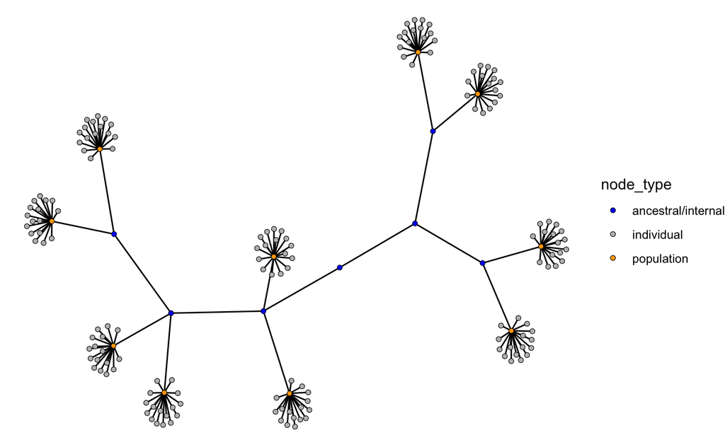

```r
tree_check$plots$tree_without_names
```

We see our samples of 16 fish from each of 10 populations.

Here we see it with the internal nodes labelled:

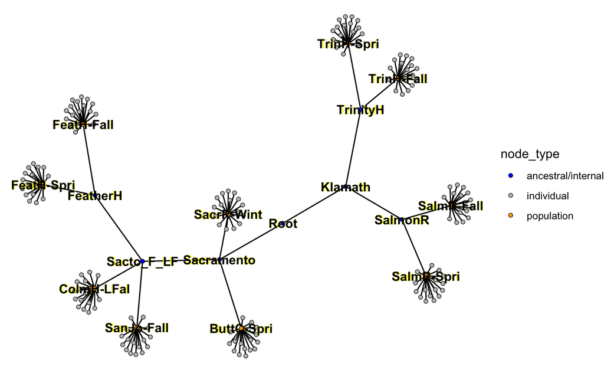

```r
tree_check$plots$tree_with_names
```

If you want to see it as a more traditional dendrogram, you can access the dendrogram version of the plot:

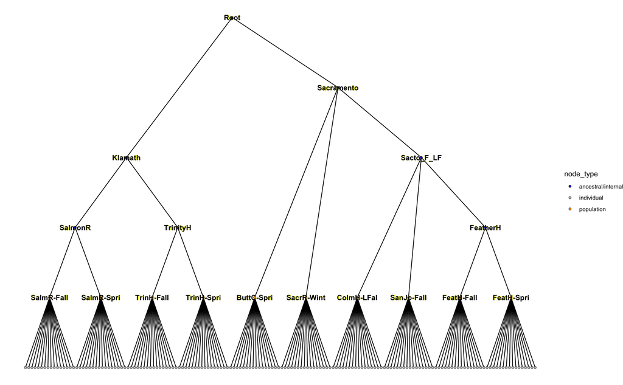

```r
tree_check$plots$dendrogram_with_names
```

## Finally, prepare the tree for input to the $F_\mathrm{ST}$ function

Once we are satisfied that our tree is correct, we can run `prepare_treelist()` again with the sample names in the order that they appear in the VCF file. Doing so causes the function to convert the tree into an integer-based specification that is easy to pass into C++. To do this, we must also pass it the names of the individuals in the VCF file from which we made the text file of allele depths.

```r
vcf_names = read_lines("~/Downloads/vcf_sample_names.txt")
input_for_srs <- prepare_treelist(
  treelist = treelist,
  vcf_names = vcf_names
)
```

Just for reference, here is what the integer-representation for input looks like:

```r
input_for_srs$srs_id_input
```

```
$pops_of_indivs
  [1] 5 5 6 6 2 2 3 3 9 9 8 8 5 5 6 6 2 2 3 3 9 9 8 8 5 5 6 6 2 2 3 3 9 9 8 8 5 5 6 6 2 2 3 3
 [45] 9 9 8 8 5 5 6 6 2 2 3 3 9 9 8 8 5 5 6 6 2 2 3 3 9 9 8 8 5 5 6 6 2 2 3 3 9 9 8 8 5 5 6 6
 [89] 2 2 3 3 9 9 8 8 7 7 1 1 4 4 0 0 7 7 1 1 4 4 0 0 7 7 1 1 4 4 0 0 7 7 1 1 4 4 0 0 7 7 1 1
[133] 4 4 0 0 7 7 1 1 4 4 0 0 7 7 1 1 4 4 0 0 7 7 1 1 4 4 0 0

$num_pops
[1] 10

$num_internal_nodes
[1] 17

$non_pop_internal_node_daughters
$non_pop_internal_node_daughters$SalmonR
[1] 5 6

$non_pop_internal_node_daughters$TrinityH
[1] 8 9

$non_pop_internal_node_daughters$FeatherH
[1] 2 3

$non_pop_internal_node_daughters$Klamath
[1] 10 11

$non_pop_internal_node_daughters$Sacto_F_LF
[1] 12  1  7

$non_pop_internal_node_daughters$Sacramento
[1] 14  0  4

$non_pop_internal_node_daughters$Root
[1] 15 13
```

# Compute population-specific $F_\mathrm{ST}$

Now we just feed `input_for_srs` and the text file of allele depths into the function `pop_specific_fst()` to get the $F_\mathrm{ST}$ values. We only do 10 bootstrap replicates, here, to save time. But you would typically want to do more. On the example data, this takes about 15 seconds.

```r
Fsts <- pop_specific_fst(
  in_list = input_for_srs,
  AD_file = "~/Downloads/two-small-chromos-flat.txt",
  boot_reps = 10
)
```

Here is what the output looks like

```r
Fsts
```

| parent | daughter | parent_idx | daughter_idx | fst_boot_reps | fst_est | min_boot | max_boot |
| --- | --- | --- | --- | --- | --- | --- | --- |
| SalmonR | SalmR-Fall | 11 | 6 |  | 0.004838598 | 0.001749997 | 0.006638815 |
| SalmonR | SalmR-Spri | 11 | 7 |  | 0.019331181 | 0.015279291 | 0.022024376 |
| TrinityH | TrinH-Fall | 12 | 9 |  | 0.013760103 | 0.011769845 | 0.014396864 |
| TrinityH | TrinH-Spri | 12 | 10 |  | 0.004246321 | 0.002357960 | 0.004817914 |
| FeatherH | FeatH-Fall | 13 | 3 |  | 0.002988454 | 0.001793622 | 0.003813144 |
| FeatherH | FeatH-Spri | 13 | 4 |  | 0.016253239 | 0.015061150 | 0.017501742 |
| Klamath | SalmonR | 14 | 11 |  | -0.003391486 | -0.005724745 | -0.001593142 |
| Klamath | TrinityH | 14 | 12 |  | 0.028003750 | 0.026303164 | 0.028702797 |
| Sacto_F_LF | FeatherH | 15 | 13 |  | -0.024070437 | -0.025440005 | -0.023730761 |
| Sacto_F_LF | ColmH-LFal | 15 | 2 |  | 0.020197023 | 0.019395313 | 0.021532454 |

[output cut: 6 more lines]